# Words - Capstone

Suharkov MP

14 12 2020

```r
library(dplyr) #dataframe formatting
library(stringr) #string formatting
library(readr) #txt to string
library(tm) #text analisys
library(RWeka) #searching for n-grams
library(ggplot2)

#for cloud
library(wordcloud)
library(wordcloud2)
library(RColorBrewer)
```

# Overview

In my work I will use the en_US locale of the dataset.

```r
blogs <- as.data.frame(readLines('./final/en_US/en_US.blogs.txt'))
names(blogs) <- c('Text')
blogs <- blogs %>% mutate(length = nchar(blogs$Text)) %>%
  mutate(words = sapply(strsplit(blogs$Text, ' '), length))

news <- as.data.frame(readLines('./final/en_US/en_US.news.txt'))
names(news) <- c('Text')
news <- news %>% mutate(length = nchar(news$Text)) %>%
  mutate(words = sapply(strsplit(news$Text, ' '), length))

twitter <- as.data.frame(readLines('./final/en_US/en_US.twitter.txt'))
names(twitter) <- c('Text')
twitter <- twitter %>% mutate(length = nchar(twitter$Text)) %>%
  mutate(words = sapply(strsplit(twitter$Text, ' '), length))

Names <- c('Word counts', 'Line counts', 'File size, MB')
Blog <- c(sum(blogs$words),
          length(readLines('./final/en_US/en_US.blogs.txt')),
          round(file.size(paste0(getwd(), '/final/en_US/en_US.blogs.txt')) / 1024^2, digits = 2))
News <- c(sum(news$words),
          length(readLines('./final/en_US/en_US.news.txt')),
          round(file.size(paste0(getwd(), '/final/en_US/en_US.news.txt')) / 1024^2, digits = 2))
Twitter <- c(sum(twitter$words),
             length(readLines('./final/en_US/en_US.twitter.txt')),
             round(file.size(paste0(getwd(), '/final/en_US/en_US.twitter.txt')) / 1024^2, digits = 2))
t1 <- data.frame(Blog, News, Twitter)
row.names(t1) <- c('Word counts', 'Line counts', 'File size, MB')
t1
```

```
##                      Blog       News     Twitter
## Word counts   37334131.00 2643969.00 30373543.00
## Line counts     899288.00   77259.00  2360148.00
## File size, MB      200.42     196.28      159.36
```

To decide what part of this huge pack of data to use, I want to look at the distribution of lengths for each of three files. According to this, I will load while files onto memory and filter data afterwards. Next step is to look at these sets’ percentiles to decide, how much data will be used for building model.

```r
quantile(blogs$length, c(.01, .05, .1, .2, .3, .4, .5, .6, .7, .8, .9, .95, .99, .9999))
```

```
##       1%       5%      10%      20%      30%      40%      50%      60%
##    8.000   16.000   23.000   38.000   60.000   99.000  157.000  219.000
##      70%      80%      90%      95%      99%   99.99%
##  288.000  382.000  538.000  699.000 1120.000 3434.214
```

```r
quantile(news$length, c(.01, .05, .1, .2, .3, .4, .5, .6, .7, .8, .9, .95, .99, .9999))
```

```
##       1%       5%      10%      20%      30%      40%      50%      60%
##   13.000   27.000   49.000   93.000  127.000  157.000  186.000  216.000
##      70%      80%      90%      95%      99%   99.99%
##  250.000  293.000  363.000  432.000  631.000 1594.371
```

```r
quantile(twitter$length, c(.01, .05, .1, .2, .3, .4, .5, .6, .7, .8, .9, .95, .99, .9999))
```

```
##     1%     5%    10%    20%    30%    40%    50%    60%    70%    80%    90%
##     10     16     22     32     42     53     64     77     92    108    124
##    95%    99% 99.99%
##    132    140    146
```

# Task 1 - Getting and cleaning the data

```r
blogs <- blogs %>% filter(length > 3000)
news <- news %>% filter(length > 1500)
#too much of twits make my PC not able to count vectors, so I have to cut it a little
twitter <- twitter %>% filter(length > 146)
```

Next, I will write these to a new dataframe, then to string in order to continue working with it.

```r
sample <- bind_rows(blogs, news, twitter)
sample <- paste0(sample$Text)
#Prevent future errors with non-UTF-8 characters
sample <- stringr::str_conv(sample, "UTF-8")
```

## Tokenization

I will use the **tm** package for this part of analysis. It’s suitable for text mining, transforming words or strings into *word corpus*, cleaning the data (removing numbers, punctuation, web links, stop words etc.) and each of this steps can be done by one separate function. The package and algorithm were chosen according to this video: (Data Science Tutorial | Text analytics with R)[https://www.youtube.com/watch?v=qjSeedeF4KQ], thanks to the author.

```r
corpus <- Corpus(VectorSource(sample))
inspect(corpus[1:3])
```

```
## <<SimpleCorpus>>
## Metadata:  corpus specific: 1, document level (indexed): 0
## Content:  documents: 3
##
## [1] The improvement of the blacks in body and mind, in the first instance of their mixture with the whites, has been observed by every one, and proves that their inferiority is not the effect merely of their condition of life. We know that among the Romans, about the Augustan age especially, the …
## [2] All of this society 101 has sprung from several people over the last week telling us that they envy our lifestyle. Steve and I just turn to each other in wonderment whenever anyone would even think of wanting to do what we do every day. I guess it’s the grass is greener meets the photos that …
## [3] Few people have enjoyed a closer association with jump racing in the last 30 years than John Patrick ’J P’ McManus, who was born on a farm in Co Limerick on March 10, 1951 and attended the Christian Brothers school on Sexton Street, Limerick. He left his father’s plant hire business at the ag…
```

There are numbers, punctuation signs, parenthesis and some specific symbols, like **£**. Also short versions of words, but they make it impossible to predict, what form is it. I have **fix’d** for **fixed** and **’d** can also mean **should/would**. I will not even try to guess, just wipe all these forms.

```r
#Built-in cleaning functions
corpus <- corpus %>%
  tm_map(tolower) %>%
  tm_map(removeNumbers) %>%
  tm_map(removePunctuation) %>%
  tm_map(removeWords, stopwords()) %>%
  tm_map(stripWhitespace)
```

## Profanity filtering

I’ve found a very large list of profanity words which I will use here as a filter - (School of Computer Science at Carnegi Mellon University)[https://www.cs.cmu.edu/~biglou/resources/bad-words.txt]

```r
#download.file('https://www.cs.cmu.edu/~biglou/resources/bad-words.txt', 'profanity.txt')
prof <- readLines('profanity.txt')
corpus <- tm_map(corpus, removeWords, prof)
#Make matrix
dtm <- DocumentTermMatrix(corpus)
```

Corpus’ size did not change, I think there were no profanity from this list. That’s nice.

```r
inspect(dtm)
```

```
## <<DocumentTermMatrix (documents: 384, terms: 15137)>>
## Non-/sparse entries: 44337/5768271
## Sparsity           : 99%
## Maximal term length: 128
## Weighting          : term frequency (tf)
## Sample             :
##      Terms
## Docs  can get interests just like one public time vested will
##   104   8   1         2    3    0   3     25    2      0    6
##   120   2   1         2    3    0   8     73    3      0    9
##   20    5   2         1    0    1   6     27    1      0   22
##   51    1   1         0    3    0   3      2    3      0    1
##   54    3   1         1    0    5   3      0    1      0   11
##   70   10   1         0    3    5  13      0   10      0   21
##   73    7   1         0    1    1   6      3    7      0   19
##   76    1   4         0    2    2   4      0    3      0    2
##   81    0   1         0    0    0   5      0    2      0    0
##   85   31   3         2    1    1  15    119    5      0   37
```

This **’s** doesn’t look like the word suitable for corpus. I will make now some more manipulations to purge it. The same to different kinds of parenthesis, dots etc (these *words* were found through several iterations, while working with word cloud).

```r
toSpace <- content_transformer(function(x, pattern) gsub(pattern, ' ', x))
toNot <- content_transformer(function(x, pattern) gsub(pattern, ' not', x))
corpus1 <- corpus %>%
  tm_map(toSpace, "’s") %>%
  tm_map(toSpace, "“") %>%
  tm_map(toSpace, "–") %>%
  tm_map(toSpace, "”") %>%
  tm_map(toSpace, "’m") %>%
  tm_map(toSpace, "’re") %>%
  tm_map(toSpace, "’ve") %>%
  tm_map(toSpace, "’d") %>%
  tm_map(toSpace, "’ll") %>%
  tm_map(toSpace, "…") %>%
  tm_map(toSpace, "—") %>%
  tm_map(toNot, "n’t") %>%
  tm_map(stripWhitespace)
dtm <- DocumentTermMatrix(corpus1)
inspect(dtm)
```

```
## <<DocumentTermMatrix (documents: 384, terms: 14324)>>
## Non-/sparse entries: 43520/5456896
## Sparsity           : 99%
## Maximal term length: 128
## Weighting          : term frequency (tf)
## Sample             :
##      Terms
## Docs  can interests just like not one public time vested will
##   104   8         2    3    0   0   3     25    2      0    6
##   120   2         2    3    0   0   8     73    3      0    9
##   20    5         1    0    1   0   6     27    1      0   22
##   51    1         0    3    0   0   3      2    3      0    1
##   54    3         1    0    5   0   3      0    1      0   11
##   70   11         0    5    6  15  18      0   15      0   21
##   73    7         0    1    1   0   6      3    7      0   19
##   76    1         0    2    2   4   4      0    3      0    2
##   81    0         0    0    0   0   5      0    2      0    0
##   85   31         2    1    1   0  15    120    5      0   37
```

## Cloud

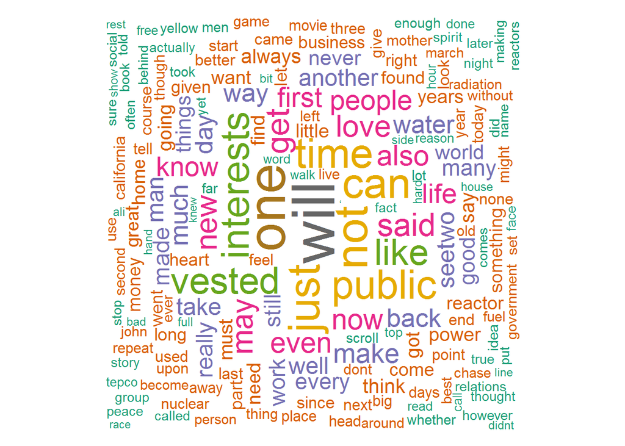

```r
matrix <- as.matrix(dtm)
words <- sort(colSums(matrix), decreasing = TRUE)
df <- data.frame(word = names(words), freq = words)
set.seed(42) # for reproducibility
wordcloud(words = df$word, freq = df$freq,
          min.freq = 1,
          max.words = 300,
          random.order = FALSE,
          rot.per = 0.35,
          colors = brewer.pal(8, 'Dark2'))
```

Now it’s questions’ time.

# Task 2 - Exploratory Data Analysis

## Question 1

Some words are more frequent than others - what are the distributions of word frequencies?

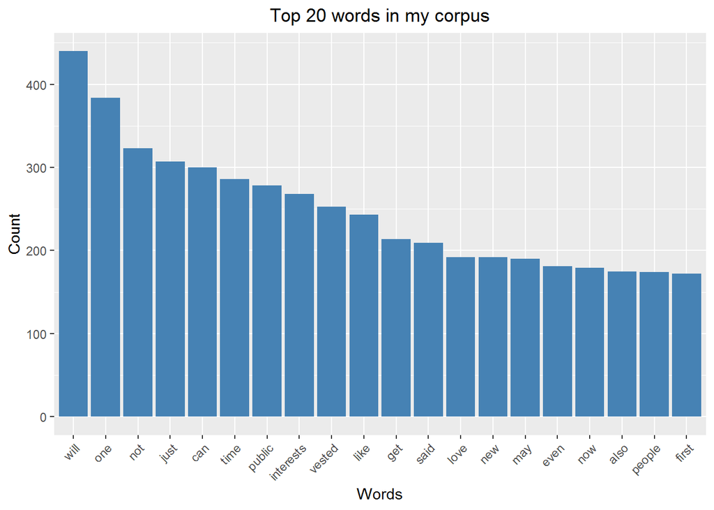

```r
topwords <- as.data.frame(words[1:20])
topwords <- topwords %>% mutate(words = rownames(topwords))
names(topwords) <- c('count', 'word')
ggplot(topwords, aes(x = reorder(word, -count), y = count)) +
  geom_bar(stat = 'identity', fill = 'steelblue') +
  theme(axis.text.x = element_text(angle = 45, hjust = 1),
        plot.title = element_text(hjust = 0.5)) +
  labs(x = 'Words', y = 'Count', title = 'Top 20 words in my corpus')
```

And **will** is the winner.

## Question 2

What are the frequencies of 2-grams and 3-grams in the dataset?

```r
#For making n-grams, corpus must be trasformed
vCorpus <- VCorpus(VectorSource(corpus))
```

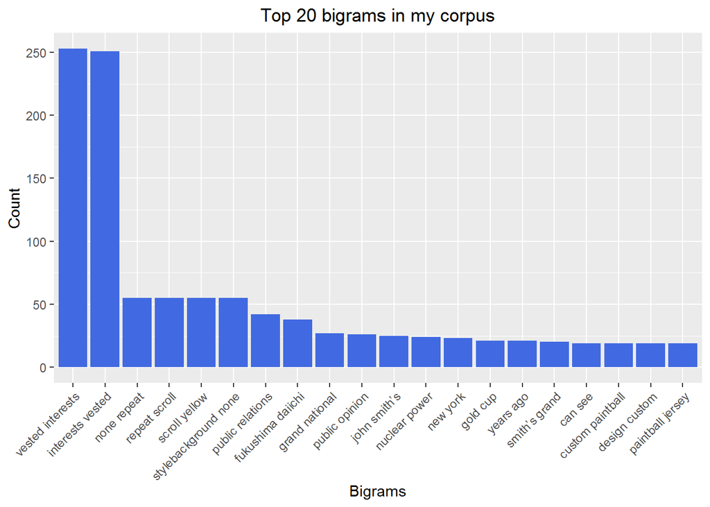

```r
#Bigrams
BigramTokenizer <- function(x) {NGramTokenizer(x, Weka_control(min = 2, max = 2))}
dtm2 <- TermDocumentMatrix(vCorpus, control = list(tokenize = BigramTokenizer))
matrix2 <- as.matrix(dtm2)
bigrams <- sort(rowSums(matrix2), decreasing = TRUE)
df2 <- data.frame(word = names(bigrams), freq = bigrams)
topbis <- as.data.frame(bigrams[1:20])
topbis <- topbis %>% mutate(words = rownames(topbis))
names(topbis) <- c('count', 'bigram')
ggplot(topbis, aes(x = reorder(bigram, -count), y = count)) +
  geom_bar(stat = 'identity', fill = 'royalblue') +
  theme(axis.text.x = element_text(angle = 45, hjust = 1),
        plot.title = element_text(hjust = 0.5)) +
  labs(x = 'Bigrams', y = 'Count', title = 'Top 20 bigrams in my corpus')
```

```r
rm(matrix2)
```

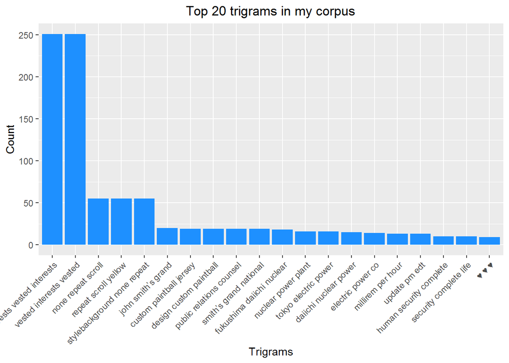

```r
#Trigrams
TrigramTokenizer <- function(x) {NGramTokenizer(x, Weka_control(min = 3, max = 3))}
dtm3 <- TermDocumentMatrix(vCorpus, control = list(tokenize = TrigramTokenizer))
matrix3 <- as.matrix(dtm3)
trigrams <- sort(rowSums(matrix3), decreasing = TRUE)
df3 <- data.frame(word = names(trigrams), freq = trigrams)
toptris <- as.data.frame(trigrams[1:20])
toptris <- toptris %>% mutate(trigrams = rownames(toptris))
names(toptris) <- c('count', 'trigram')
ggplot(toptris, aes(x = reorder(trigram, -count), y = count)) +
  geom_bar(stat = 'identity', fill = 'dodgerblue') +
  theme(axis.text.x = element_text(angle = 45, hjust = 1),
        plot.title = element_text(hjust = 0.5)) +
  labs(x = 'Trigrams', y = 'Count', title = 'Top 20 trigrams in my corpus')
```

```r
rm(matrix3)
```

Twitter really rules with it’s emojis, #20 is **💗💗💗**

## Question 3

How many unique words do you need in a frequency sorted dictionary to cover 50% of all word instances in the language? 90%?

It can be predicted only according to the used corpus.

```r
length(words)
```

```
## [1] 14324
```

```r
sum(words)
```

```
## [1] 67068
```

So, I have 14324 unique words and 67068 total.

Changing the column to cumulative sum and estimating the amount of words equal to 50% and 90% will give the answer:

```r
words <- cumsum(words)
print(paste0(sum(words < ceiling(67068 * 0.5)), ' words cover 50%'))
```

```
## [1] "832 words cover 50%"
```

```r
print(paste0(sum(words < ceiling(67068 * 0.9)), ' words cover 90%'))
```

```
## [1] "7617 words cover 90%"
```

## Question 4

How do you evaluate how many of the words come from foreign languages?

### Answer 4

This could be done by filtering all the symbols except [a-zA-Z]. But it should be done carefully, some foreign words get into this regular expression (for example, not all spanish words have **Ñ** inside).

## Question 5

Can you think of a way to increase the coverage – identifying words that may not be in the corpora or using a smaller number of words in the dictionary to cover the same number of phrases?

### Answer 5

This task should use stemming before teaching the model and applying grammar rules then predicting.